# Hypothesis Testing

## Readings

- Gelman and Loken (2014): The statistical crisis in science
- Nuzzo (2014): Statistical errors

## Hypotheses

**Hypothesis**: a statement that can be either true or false

**Statistical hypothesis**: a hypothesis about about a parameter (or parameters) of a population or process

- Many statistical analyses have the goal of performing a hypothesis test.

**Three Frameworks** : Analytical, Maximum Likelihood, Bayesian

## Analytical

- Calculate test statistic
- Determine *P*-value (area under tail(s))

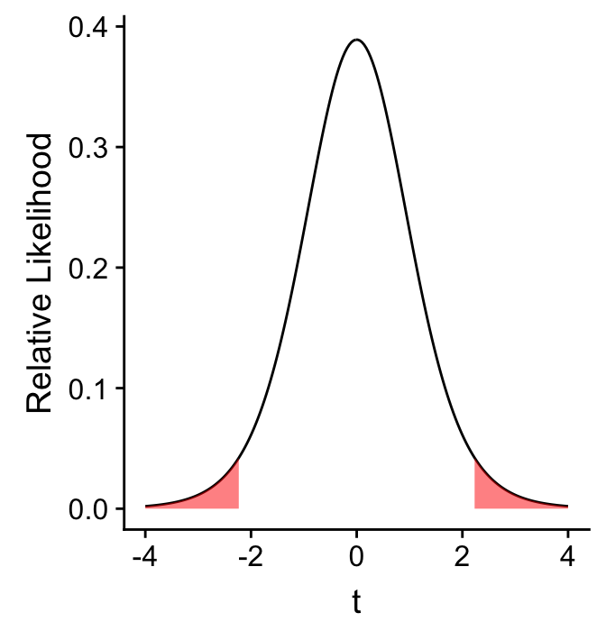

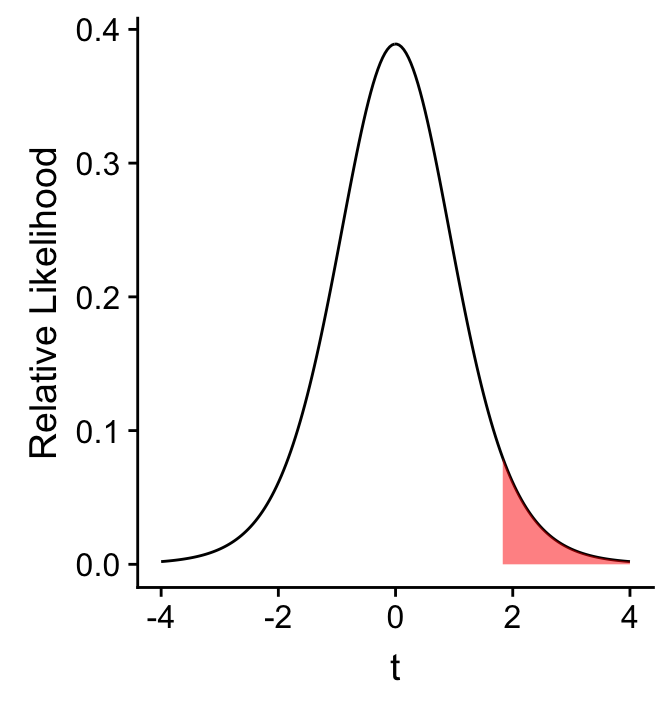

## One sided or two-sided tests

Data will always be on one side of H<sub>0</sub> or the other.

**One-sided test** (“one-tailed”):

- Appropriate when we have an *a priori* hypothesis of the direction of change
- You need justification and to be explicit about it, when you report a one-sided test.

**Two-sided test** (“two-tailed”):

- *Appropriate at all other times.*
- Multiply the one-sided *P* by 2.
  - Don’t forget to do this.

## Analytical

- Calculate test statistic
- Determine *P*-value (area under tail(s))

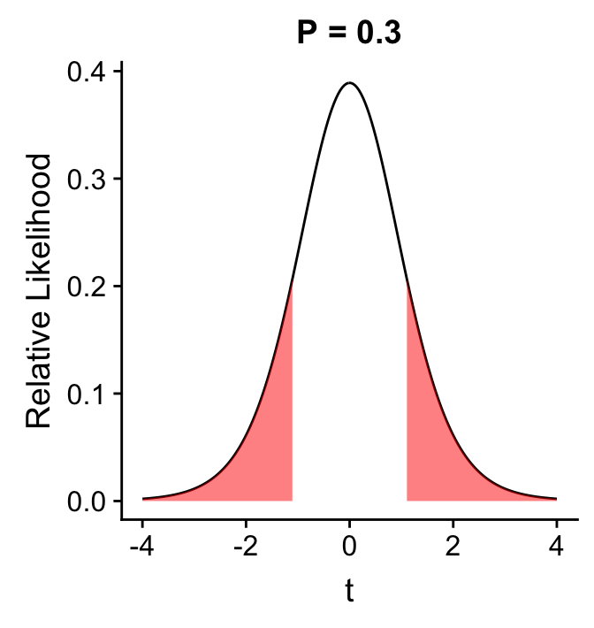

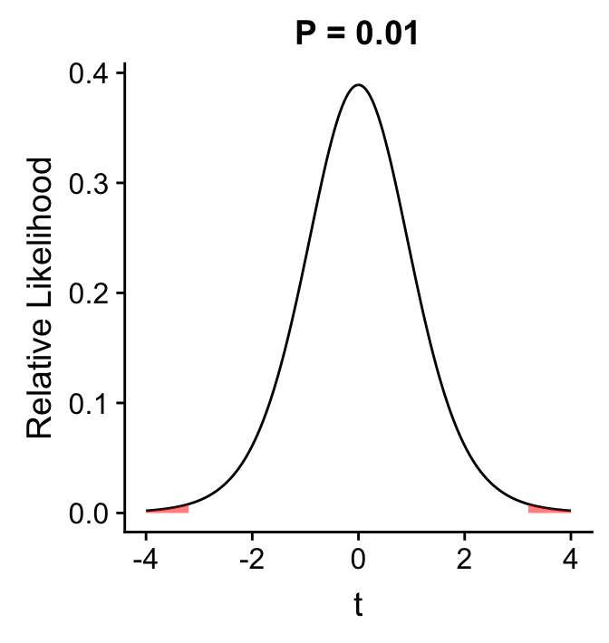

## Maximum Likelihood

- Does a given model explain significantly more variation than a model with fewer parameters?
- Likelihood ratios
  - Likelihood of Model 2 (more parameters)/Likelihood of Model 1 (fewer parameters)
  - Follow a \(\chi^2\) Distribution (df = difference in number of estimated parameters)

*Stay Tuned for Model Comparisons*

## Bayesian Inference

- Does the Credible Interval of a given parameter estimate encompass the value in question. e.g.,:
  - Does the credible interval for the difference in means include zero?
  - Does the credible interval for the parameter estimate include 98.6?

## Tests of arbitrary slopes and intercepts

\[t = \frac{b - \beta_{0}}{\mbox{SE}_{b}}\]

is a general equation that can be used to test any null hypothesized parameter estimate.

- \(b\) is the parameter estimate, \(\beta_0\) is the null hypothesized value (often and by default \(\beta_0 = 0\))
- Analyses of allometry: the study of scaling relationships

## PanTHERIA: Database of mammal life history data

Data from Jones et al (2009)

*AdultBodyMass_g*: Mass of adult (or age unspecified) live or freshly-killed specimens (excluding pregnant females) using captive, wild, provisioned, or unspecified populations; male, female, or sex unspecified individuals; primary, secondary, or extrapolated sources; all measures of central tendency; in all localities.

*AdultForearmLen_mm*: Total length from elbow to wrist of adult (or age unspecified) live, freshly-killed, or museum specimens using captive, wild, provisioned, or unspecified populations; male, female, or sex unspecified individuals; primary, secondary, or extrapolated sources; all measures of central tendency; in all localities.

## Examine the data

```r
glimpse(mammals)
```

```
## Observations: 662
## Variables: 4
## $ Order   <chr> "Chiroptera", "Chiroptera", "Chiroptera", "Chiroptera", …
## $ Species <chr> "Balantiopteryx io", "Balantiopteryx plicata", "Balionyc…
## $ Mass    <dbl> 3.97, 6.57, 14.43, 15.42, 20.71, 15.17, 20.14, 21.83, 10…
## $ Forearm <dbl> 37.00, 42.23, 40.96, 48.99, 46.50, 44.94, 47.00, 46.39, …
```

## Preliminary plotting

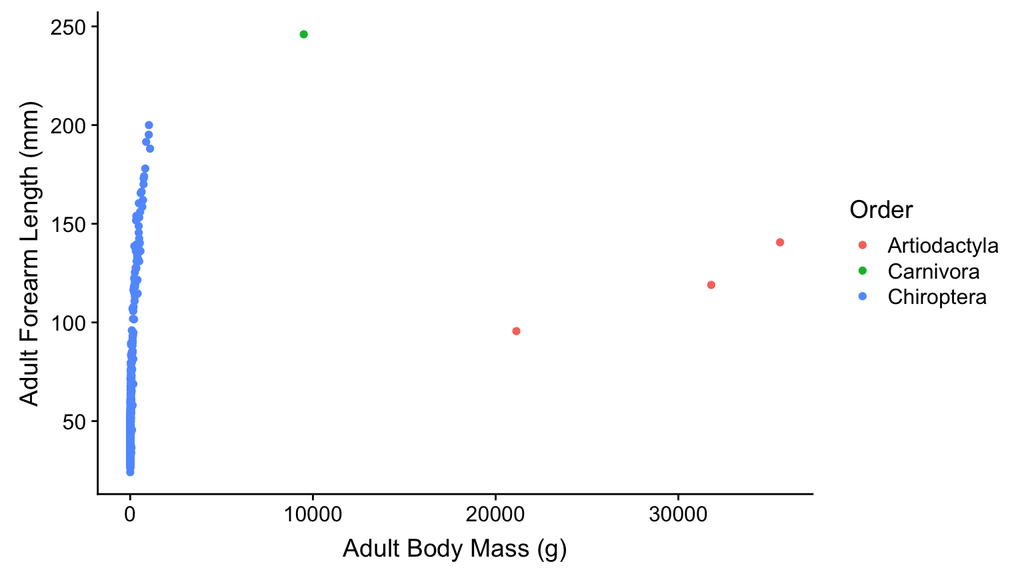

## Drop the really large mammals

Observations:

1. Very few large mammals in the sample
2. “Large” mammals (> 5 kg) might have a different scaling pattern from the smaller ones (at least in the sample)
3. Only bats remain

```r
# Drop all rows with Mass >= 5000 g
mammals <- mammals %>% filter(Mass <= 5000)
```

## Replot

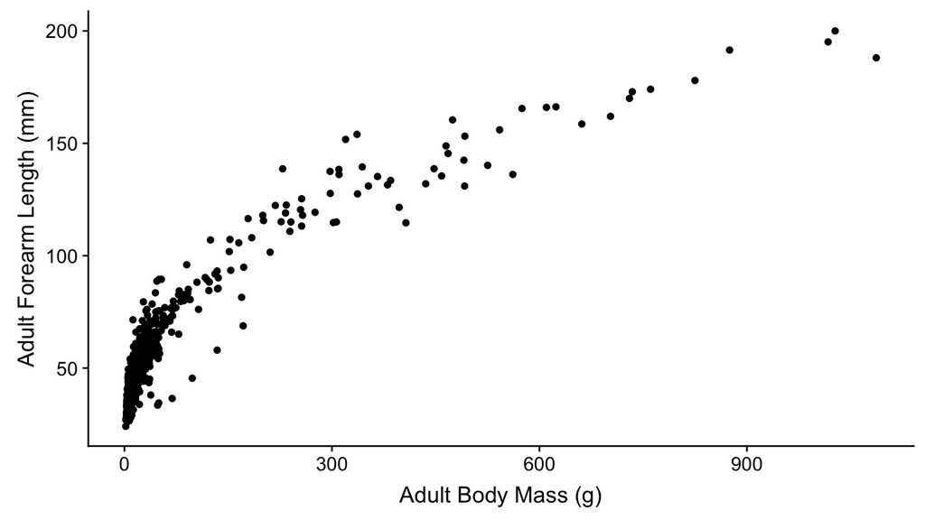

## Scaling relationships

> “In biology, constancy in shape with change in size is termed *isometric growth* (or *isometry*), the usual null hypothesis in morphological scaling studies.” LaBarbera (1989)

Lengths are linearly proportional to lengths:

\[L_1 \propto L_2\]

Area is proportional to a length squared:

\[A \propto L^2\]

Volume (mass) is proportional to a length cubed:

\[V \propto L^3\]

## Log transformation

The power law relationship:

\[Y = a \centerdot M^b\]

Can be linearized by logging (natural or otherwise) both sides of the equation:

\[\log{Y} = \log{a} + b \log{M}\]

## Plotting on log-log scale

```r
ggplot(mammals, aes(x = Mass, y = Forearm)) +
  geom_point() +
  xlab("Adult Body Mass (g)") +
  ylab("Adult Forearm Length (mm)") +
  scale_x_log10() +
  scale_y_log10()
```

## Plotting on log-log scale

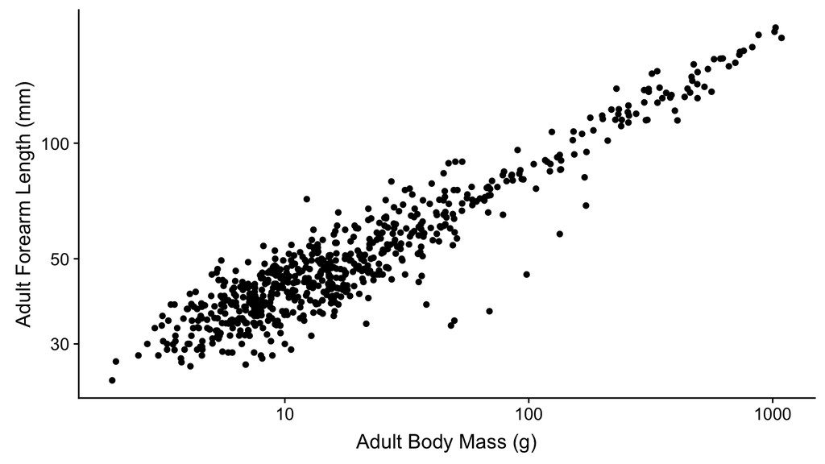

## Caution about working in log space

In this case log<sub>10</sub>:

> “It is probably difficult, for example, to appreciate that points quite close together, such as with log values of 4.90 and 4.60, are the difference on a linear scale between about 79,000 and 40,000.” Smith (1984)

## Log-transformation

```r
mammals <- mammals %>%
  mutate(log_Mass = log10(Mass),
         log_Forearm = log10(Forearm))
glimpse(mammals)
```

```
## Observations: 658
## Variables: 6
## $ Order       <chr> "Chiroptera", "Chiroptera", "Chiroptera", "Chiropter…
## $ Species     <chr> "Balantiopteryx io", "Balantiopteryx plicata", "Bali…
## $ Mass        <dbl> 3.97, 6.57, 14.43, 15.42, 20.71, 15.17, 20.14, 21.83…
## $ Forearm     <dbl> 37.00, 42.23, 40.96, 48.99, 46.50, 44.94, 47.00, 46.…
## $ log_Mass    <dbl> 0.5987905, 0.8175654, 1.1592663, 1.1880844, 1.316180…
## $ log_Forearm <dbl> 1.568202, 1.625621, 1.612360, 1.690107, 1.667453, 1.…
```

## OLS regression on logged data

```r
fm <- lm(log_Forearm ~ log_Mass, data = mammals)
summary(fm)
```

```
##
## Call:
## lm(formula = log_Forearm ~ log_Mass, data = mammals)
##
## Residuals:
##       Min        1Q    Median        3Q       Max
## -0.313443 -0.034269  0.003279  0.041851  0.208750
##
## Coefficients:
##             Estimate Std. Error t value Pr(>|t|)
## (Intercept) 1.310586   0.006195  211.57   <2e-16 ***
## log_Mass    0.307339   0.004427   69.42   <2e-16 ***
## ---
## Signif. codes:  0 '***' 0.001 '**' 0.01 '*' 0.05 '.' 0.1 ' ' 1
##
## Residual standard error: 0.06286 on 656 degrees of freedom
## Multiple R-squared:  0.8802, Adjusted R-squared:   0.88
## F-statistic:  4819 on 1 and 656 DF,  p-value: < 2.2e-16
```

## Test of a specific slope

Isometric slope \(= \beta_0 = Mass^{1/3}\)

\[t = \frac{b - \beta_0}{SE_b}\]

```
            Estimate Std. Error t value Pr(>|t|)
log_Mass    0.307339   0.004427   69.42   <2e-16
```

```r
(t_value <- (0.307339 - (1 / 3)) / 0.004427)
```

```
## [1] -5.871772
```

```r
2 * pt(t_value, df = 658 - 2)
```

```
## [1] 6.85076e-09
```

## Caveats

Think about your power to detect an effect.

- Context for “not significant” results.
- Context for “significant” results.

Think about error in measurement of Body Mass

- OLS regression assumes \(x\) measured with no error.

Think about independence of observations

- Bats are phylogenetically closely related

## Types of errors and statistical power

|  | Reject H<sub>0</sub> | Fail to reject H<sub>0</sub> |
| --- | --- | --- |
| H<sub>0</sub> is true | Type I error | *Correct* |
| H<sub>0</sub> is false | *Correct* | Type II error |

Type I error occurs when:

- *P* is small by *random chance*, given that \(\alpha\) is chosen ahead of the test

Type II error probability depends on:

- The value of \(\alpha\)
- How “wrong” H<sub>0</sub> is

## Power

- Probability that a random sample will lead to a rejection of H<sub>0</sub>
- Dependent on how different the truth is from the null hypothesis
- Inversely related to type II errors
  - High power \(\rightarrow\) low type II errors
  - Low power \(\rightarrow\) high type II errors
- Power analysis will come later (Experimental Design, etc.)

## Controversy

Philosophical and practical problems have been raised since the 1960’s.

- In 1986, the *American Journal of Public Health* told all researchers wanting to publish in the journal that he would no longer accept results based on *P*-values (and then backed down 2 years later)
- *Basic and Applied Social Psychology* banned *P*-values in 2015
- In 2016, the American Statistical Association published a “Statement on *P*-Values: Context, Process, and Purpose” which critiqued the (mis)use of *P*-values.

## History

- K. Pearson: Pearson’s correlation, \(\chi^2\), eugenics
- Fisher: Fisher’s exact test, “null hypothesis”, ANOVA (*F*)
- Gosset: *t* distribution, Student’s *t*-tests, Guinness
- Neyman and E. Pearson: “null hypothesis” testing, confidence intervals, decision theory

The modern idea is traced to these statisticians, but has been warped into something different:

- Test statistics (*F*, *t*, \(\chi^2\)) applied to Neyman-Pearson “null hypotheses”
- H<sub>0</sub> becomes a straw man hypothesis of no difference or no effect

## Problem with *P*-values

- Originally an informal concept that got co-opted for what became null hypothesis significance testing (NHST)
- Apparent objectivity but actually arbitrary and dependent on the data collected and not collected
- Experimental biases (experimenter introduced, sample size)
- Science-wide publication bias

## Science-wide publication bias

Corollaries proposed by Ioannidis (2005):

1. The smaller the studies conducted in a scientific field, the less likely the research findings are to be true.
2. The smaller the effect sizes in a scientific field, the less likely the research findings are to be true.
3. The greater the number and the lesser the selection of tested relationships in a scientific field, the less likely the research findings are to be true.
4. The greater the flexibility in designs, definitions, outcomes, and analytical modes in a scientific field, the less likely the research findings are to be true.
5. The greater the financial and other interests and prejudices in a scientific field, the less likely the research findings are to be true.
6. The hotter a scientific field (with more scientific teams involved), the less likely the research findings are to be true.

## Alternative suggested approaches

Preregistration of experimental designs

1. Report parameter estimates and confidence intervals only
2. Model selection

Either of above could be done in a Likelihood or Bayesian Framework

## Quiz 06-4

Complete Quiz 06-4 on Canvas.

This is the final lecture of the week.

## References

Curran-Everett, D., and D. J. Benos. 2007. Guidelines for Reporting Statistics in Journals Published by the *American Physiological Society*: The Sequel. *Advances in Physiology Education* 31:295–298.

Gelman, A., and E. Loken. 2014. The Statistical Crisis in Science. *American scientist* 102:460–465.

Gelman, A., and H. Stern. 2006. The Difference Between “Significant” and “Not Significant” Is Not Itself Statistically Significant. *The American statistician* 60:328–331.

Ioannidis, J. P. A. 2005. Why Most Published Research Findings Are False. *PLoS Medicine* 2:e124.

Jones, K. E., J. Bielby, M. Cardillo, S. A. Fritz, J. O’Dell, C. D. L. Orme, K. Safi, W. Sechrest, E. H. Boakes, C. Carbone, C. Connolly, M. J. Cutts, J. K. Foster, R. Grenyer, M. Habib, C. A. Plaster, S. A. Price, E. A. Rigby, J. Rist, A. Teacher, O. R. P. Bininda-Emonds, J. L. Gittleman, G. M. Mace, and A. Purvis. 2009. PanTHERIA: A Species-Level Database of Life History, Ecology, and Geography of Extant and Recently Extinct Mammals. *Ecology* 90:2648–2648.

Kruschke, J. K. 2010. What to Believe: Bayesian Methods for Data Analysis. *Trends in cognitive sciences* 14:293–300.

LaBarbera, M. C. 1989. Analyzing Body Size as a Factor in Ecology and Evolution. *Annual review of ecology and systematics* 20:97–117.

Leek, J. T., and R. D. Peng. 2015. P Values Are Just the Tip of the Iceberg. *Nature* 520:612–612.

Nuzzo, R. 2014. Statistical Errors. *Nature* 506:150–152.

Smith, R. J. 1984. Allometric Scaling in Comparative Biology: Problems of Concept and Method. *American journal of physical anthropology* 246:R152–60.

Young, N. S., J. P. A. Ioannidis, and O. Al-Ubaydli. 2008. Why Current Publication Practices May Distort Science. *PLoS medicine* 5:e201.